# Analýza krízy Covid-19 na znečistenie ovzdušia v Indií

Author

Marek Holik

## Hypotéza

Na úlohu analyzovania dát som si vybral dva datasety. Prvý obsahuje hodnoty z meraní kvality ovzdušia v Indií od roku 2017 až to roku 2022, ako druhý dataset som si vybral rast počtu prípadov ochorenia Covid 19, ktorý začal v roku 2020 a obsahuje dáta do roku 2022. Predpokladal som, že počas krízy by malo dosť k výraznému poklesu znečistenia ovzdušia v tejto krajine. Pozrime sa teda, či je moja hypotéza pravdivá alebo nie.

## Znečistenie ovzdušia v Indii

Na začiatok som si vykreslil graf, ktorý reprezentuje namerané hodnoty počas 5 rokov merania. Môžeme si všimnúť, že počas letných mesiacov výrazne poklesne znečistenie a výskyt PM2.5 - čo sú častice menšie ako 0.025mm. Na prvý pohľad vidíme, že graf klesá, čiže výskyt týchto častíc klesá. Pomocou vstavanej funkcie v R sme si vedeli vytvoriť model, ktorý nám hovorí o hodnotách v grafe, že klesajú.

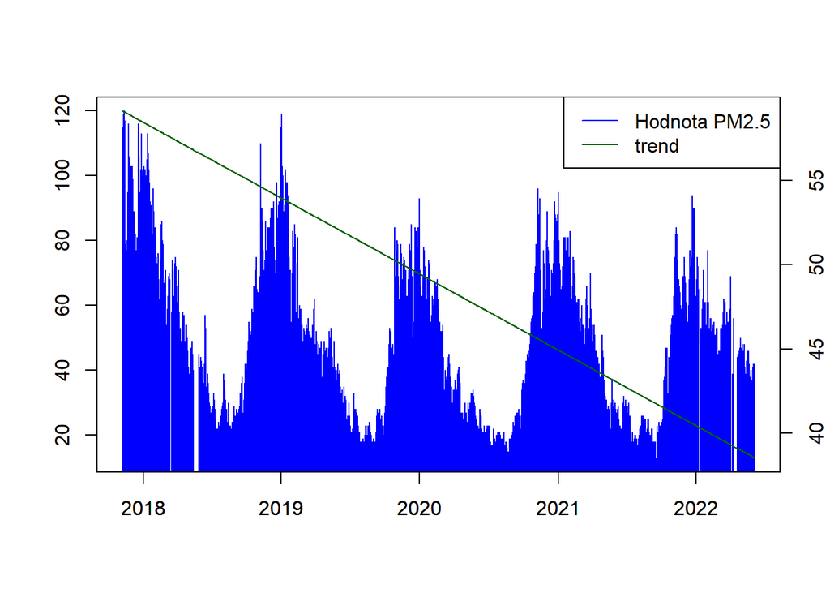

```r
mod1 = lm(priemer ~ Timestamp, data = air_quality)

grid <- air_quality %>%
    modelr::data_grid(Timestamp, priemer) %>%
    modelr::add_predictions(mod1)

plot(air_quality$Timestamp, air_quality$priemer, type="h", xlab="", ylab="",col = "blue")
par(new=TRUE)
plot(grid$Timestamp, grid$pred, type="l", xlab="", ylab="", yaxt = "n", col = "darkgreen")
axis(side=4)
legend("topright", legend=c("Hodnota PM2.5", "trend"), col=c("blue", "darkgreen"), lty=1)
```

## Prípady ochorenia Covid-19 v Indii

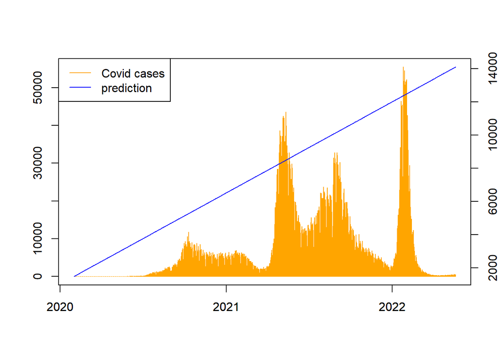

```r
mod1 = lm(Confirmed ~ Timestamp, data = covid)

grid <- covid %>%
    modelr::data_grid(Timestamp, Confirmed) %>%
    modelr::add_predictions(mod1)

plot(covid$Timestamp, covid$Confirmed, type="h", xlab="", ylab="",col = "orange")
par(new=TRUE)
plot(grid$Timestamp, grid$pred, type="l", xlab="", ylab="", yaxt = "n", col = "blue")
axis(side=4)
legend("topleft", legend=c("Covid cases", "prediction"), col=c("orange","blue"), lty=1)
```